# Supervised Machine Learning with Decision Trees and Ensemble Methods

Ted Ellsworth

3/4/2019

# A Brief Introduction to Supervised Machine Learning

- Introduction to Statistical Learning
  - Theory
  - Underlying Mechanics
- Classification and Regression Trees (CART)
- Ensemble Methods: Bootstrap Aggregating (Bagging), Random Forest

# Why Study Machine Learning for Political Science?

- Powerful tool for prediction problems: violence, electoral outcomes, classification, conflict, etc.
- Computationally efficient means for obtaining the true functional form of your model
- Useful for causal inference (Imai and Strauss)
  - Identify heterogenous treatment effects
  - Matching
  - Imputing missing data
- This is not new!

# Foundations of Statistical Learning I

- *Supervised Learning*: Predict or estimate an output $\hat{Y}$ based on a set of inputs $\hat{f}(x)$.
- *Unsupervised Learning*: We observe the inputs $\hat{f}(x)$, but include no measure of the output. Our objective is to observe the relationships and structure of our data.
- In both cases we are less interested in the functional form of $\hat{f}$ so long as it yields accurate predictions. We measure predictive performance as a function of *reducible error*.

# Foundations of Statistical Learning II

- *Parametric Statistics*: Based on prior assumptions and theory, estimate the functional form of $\hat{f}$
  - Example: $\hat{f}(x) = \beta_0 + \beta_iX_i +\epsilon$
- *Nonparametric Statistics*: Estimate $\hat{f}$ without making assumptions about its functional form. Our objective is to get close to the true value of $f$ without overfitting our model.
- *Accuracy and Interpretability Trade-Off*: less flexible models tend to be easier to interpret, but predictions are less accurate. More flexible models may yields more accurate estimates of $\hat{Y}$, but are difficult to interpret.

# Foundations of Statistical Learning III

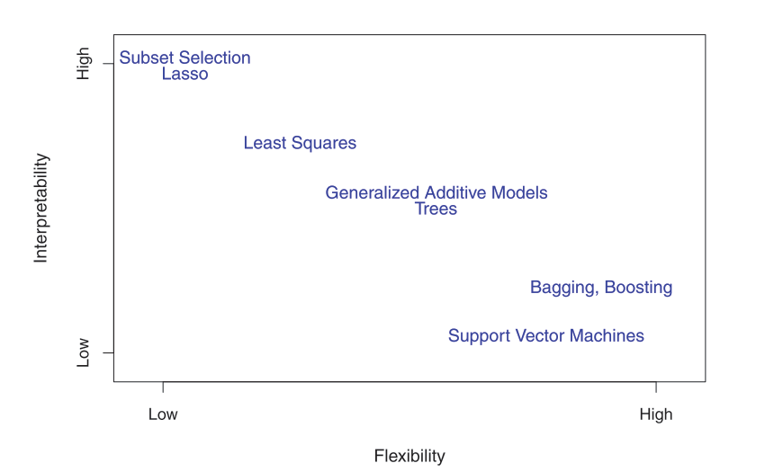

Accuracy vs. Interpretability

# Foundations of Machine Learning IV

- *The Prediction Setting*: with machine learning we are less interested in observed values (training data) and more concerned with future events (test data). Machine learning involves (at minumum) a three step process.
  - 1. Split the model into training and test data
  - 2. Fit a model to the *training data* minimize reducible error (MSE, AIC, ROC, etc.)
  - 3. Apply this model to the test data and extract the error.
- More mathmatically we say that we are not interested in whether $\hat{f}(x_i) \approx y_i$ but rather whether $\hat{f}(x_0) \approx y_0$ where $(x_0, y_0)$ is the previously unseen testing data.

# Foundations of Machine Learning V

- *Test Error*: the expected test error consists of three quantities
  - The variance of $\hat{f}(x_0)$
  - The squared bias of $\hat{f}(x_0)$
  - The variance of the error term $\epsilon$
- *Variance*: how different would $\hat{f}$ be if we had used a different training set.
- *Bias*: the amount of error introduced by estimating a real-life problem.
- *Bias Variance Trade-Off*: as model flexibility increases, bias will decrease and variance will increase.

# Foundations of Machine Learning VI

- *Accuracy*: = $\frac{Y + Y_f}{Y + Y_f + N + N_f}$
- *Precision*: = $\frac{Y}{Y + Y_f}$
- *Recall*: = $\frac{Y}{Y+ N_f}$
- *Cohens Kappa*: $-1 \leq \kappa \leq 1$

# Foundations of Machine Learning VII

- One common solution to the problem of variance is *cross-validation*
- *Cross-validation*: partitions a set of $n$ observations into non-overlapping groups or *folds*.
- Each fold acts as a validation set with the final model estimate being an averaged sum between partitions.
- Limits overfitting and reduces variance in testing procedure.

# Foundations of Machine Learning VIII

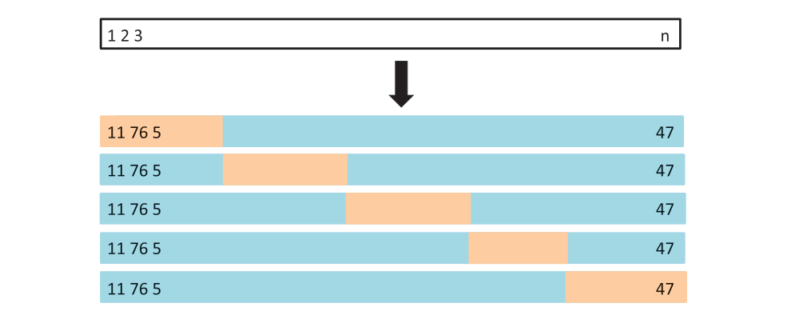

Cross-Validation: ESL

# Pros and Cons of Tree-Based Learning

- When the DGP is complex tree-based methods are more effective at detecting nonlinearities, discontinuities, and interactions.
- Mimic the process of human decision making.
- Decomposition methods allow interpretation which is much less dependent on (weak) analytical assumptions.
- Not as powerful as other ML methods (Hence we use Bagging and RF)
- Tree based models are “greedy” in that they bias categorical variables which are easier to split (there are pros and cons to this).

# Decision Trees for Political Science Research

- Tree based methods partition the data space into different regions and fit a simple model to each one.
  - The goal is to find partitions $R_1,...R_J$ that minimize the reducible error.
  - For recursive binary splitting, we select the predictor $X_j$ and the cutpoint $s$
- The predictive result of this model can be derived as:
  $$\hat{f}(X) = \sum_{m=1}^s c_mI{(X_i)\in R_m}$$

# Decision Trees

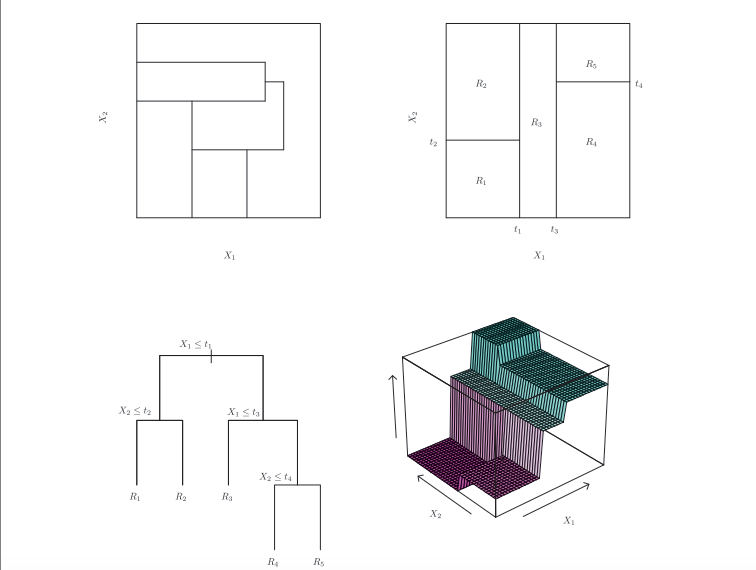

CART and Partitions: ESL

# Tree Growing

- Define regions for all $X_i$ and cutpoints $c$
- Find split $s$ which maximizes the reduction in node impurity

$$\Delta I (s,\tau) = I(\tau)- p(\tau_l)I(\tau_l)-p(\tau_R)I(\tau_R)$$
- Where I is a function of $\hat{p}_k$ the proportion of observations from class k in node $\tau$.

# Example 1: Ethnic Conflict and Civil War

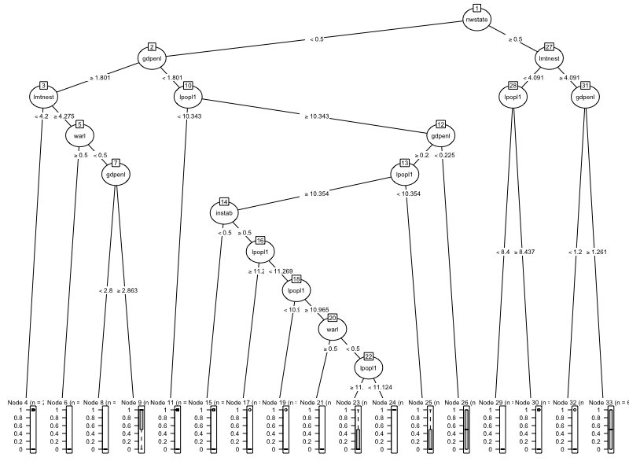

Civil War Onset w/CART

# Tree Pruning

# Example 2: Large Tree Predicting Asylum Grants

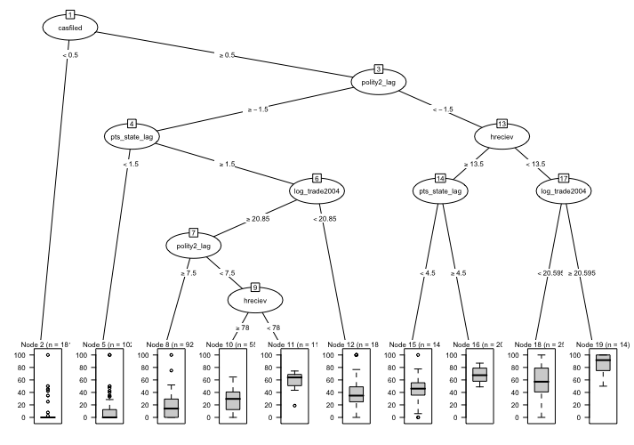

# Example 2: Cost Complexity and Model Error

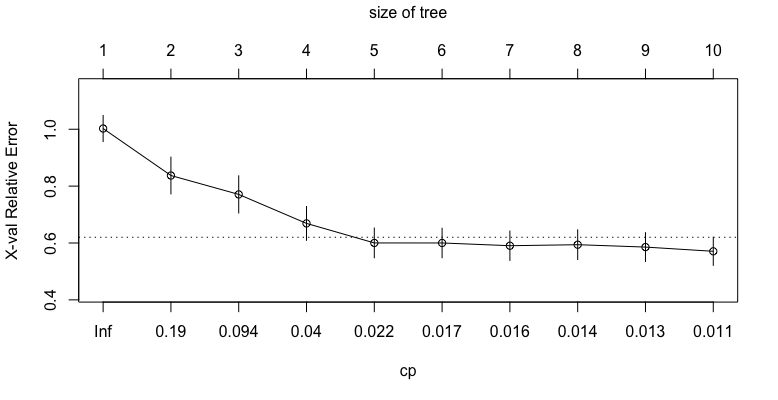

# Example 2: Pruned Decision Tree (Min)

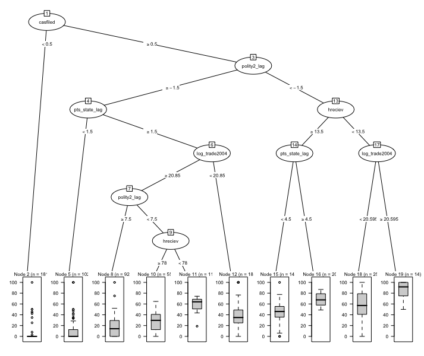

# Example 2: Pruned Decision Tree (1SE)

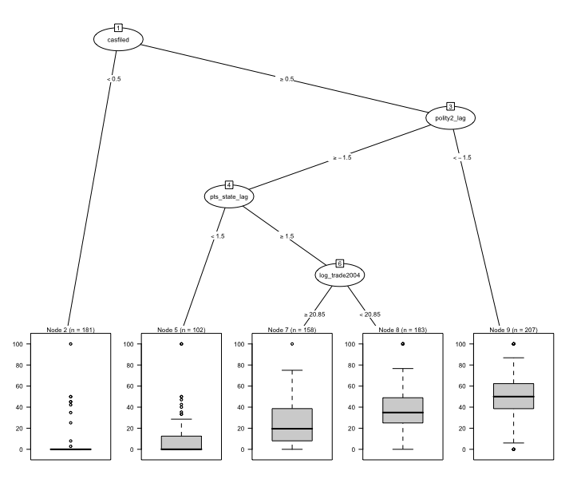

# Bootstrap Aggregating (Bagging)

- Bagging simulates the process of aggregating the results from multiple training datasets.
- Three step process:
1. Draw B bootstrap samples from the training data.
2. Build a prediction model $\hat{f}^*bx$ for each sample using base learner
3. Compute the combined prediction $\hat{f}_bag(x)$ over all samples
- Regression: $\frac{1}{B}\sum^{B}_{b=1}\hat{f}^{*b}(x)$
- Classification: $arg max_k\hat{f}_bag(x)$

# The Random Forest

- Special case of bagging where we use of subset of features per split
- With bagging we are interested in averaging over B trees to decrease variance
- Random forests go one step further by also decorrelating trees.
- To decorrelate estimates we randomly sample on rows *and columns*. Meaning we sample $B$ trees from $M$ predictor subsets.

# Mechanics of a Random Forest

- A random forest
  $${\tau_b}^{B_1}$$
  consists of a set of b = 1,2,…,B trees for prediction.
- For regression problems we average predictions over all trees:
  $$\hat{f}^B_{rf}(x)= \frac{1}{B}\sum^{B}_{b=1} \tau_b(x)$$
- For classification we are interested in the majority vote among trees:

$$\hat{C}^{B}_{rf}(x) = majorityvote{\hat{C_b(x)}}^{B}_{1}$$

# Mechanics of a Random Forest II

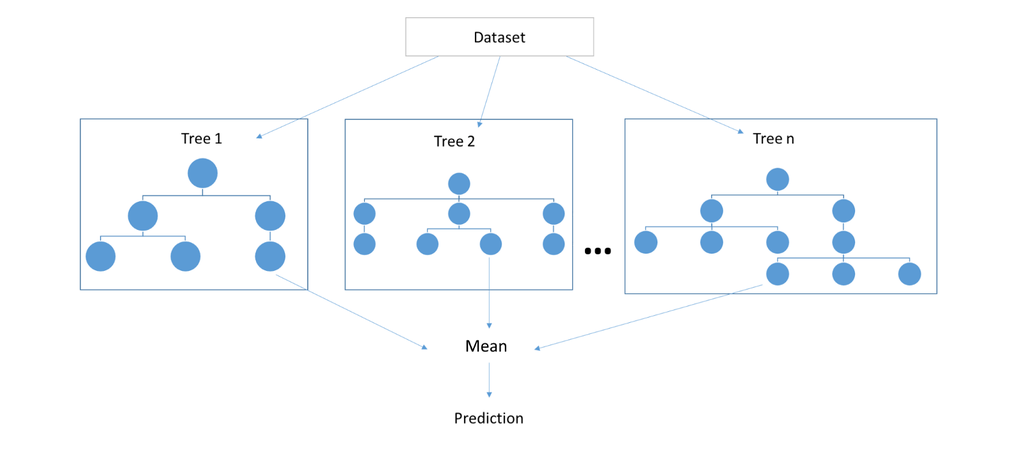

Random Forest Voting Cohort

# What do we want to learn from our models?

1. Are the features that I have selected important? Is that importance conditional?
2. What is the shape of the relationship between features and outcome?
3. How reliable is my model’s interpretation of the data?

# Measuring Model Accuracy

- A ROC curve is constructed by plotting the true positive rate (TPR) against the false positive rate (FPR).
- The ROC curve shows the trade-off between sensitivity (or TPR) and specificity (1 – FPR).
- Classifiers that give curves closer to the top-left corner indicate a better performance.
- Useful when dependent feature is imbalanced or working with rare events.
- ROC curves, out of sample test error, concusion tables, etc. give us similar information.

# Partial Dependency

- Partial dependency plots show the marginal effect of one more more features on the predicted outcome (Friedman 2001)
- We can define dependency as:

$$\hat{f}_{xs}(X_x) = E_{x_c}[\hat{f}(x_s, x_c)] = \int \hat{f}(x_s, x_c)d\mathbb{P}(x_C)$$
- $S$ represents the marginal effect on the outcome and $x^{i}_{c}$ are the actual feature values.

- PDPs have a causal intepretation. We intervene on a feature and observe a change in prediction.
- Note that this can obscure dependencies and heterogenous effects.

# Partial Dependency Plots

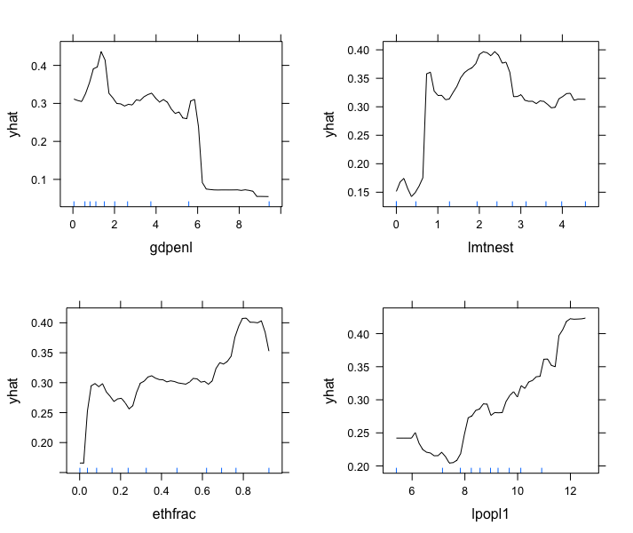

Partial Dependency Plot: Civil War States

# Individual Conditional Expectations and Local Inference

- ICE is a measure of the predictive performance of a feature for each local observation.
- Formally for each observation we estimate ${(x^{i}_{S}}, x^{i}_{c})^N$ and derive the curve $\hat{f}^{(i)}_{S}$.
- It is a good idea to center each observation at the beginning of the observed feature space. This makes it very easy to interpret.

# Ethics and Machine Learning

- The data we collect and use are not devoid of prejudices and misrepresentations
  - ‘Big-data’ tends to increase the scale of the problem.
  - If the training data include biases, the predicted outcomes will reflect them.
- The view that ML is unbiased tends to obfuscate public practice: digital redlining, micro-targeting, price discrimination.
- Sensitive political questions and predictions should be pursued with caution.
  - Can inform deterministic policy reasoning.
  - The same tools that enable us to predict outcomes in political space can inform how leaders respond to political challenges for better or for worse.

# Works Cited

- Fearon, James and David Laitin. 2003. “Ethnicity, Insurgency, and Civil War,” American Political Science Review 97(1): 75-90.
- Hastie, Trevor, Robert Tibshirani, and Jerome Friedman. 2009. Elements of Statistical Learning Second Ed. Springer.
- Kaufman, Aaron Russell, Peter Kraft, and Maya Sen. 2019. “Improving Supreme Court Forecasting Using Boosted Decision Trees,” Political Analysis. First View.
- Loh, W.Y. 2014. ”Fifty Years of Classification and Regression Trees.” International Statistical Review 82:329-348.
- Molnar, C. 2018. Interpretable Machine Learning. Retrieved from https://christophm.github.io/interpretable-ml-book/
- Montgomory, J.M. and S. Olivella. 2016. “Tree-Based Models for Political Science Data.” American Journal of Political Science 62(3):729-744.

# Works Cited

- Rottman, Andy J., C.J. Fariss, S.C. Poe. “The Path to Asylum in the US and the determinants for who gets in” International Migration Review 43(1): 3-34.
- Ward, M.D., B.D. Greenhill, and K.M. Bakke. 2010. “The Prils of Policy by p-value: Predicting Civil Conflicts,” Journal of Peace Research 47(4): 363-375